Problem Statement - Plant Seedlings Image Classification using CNNs in **Keras**

# Import all necessary modules and load the data You are provided with a dataset of images of plant seedlings at various stages of grown. Each image has a filename that is its unique id. The dataset comprises 12 plant species. The goal of the project is to create a classifier capable of determining a plant's species from a photo. Dataset: The dataset can be download from Olympus. The data file names are:  images.npy  Label.csv Steps and tasks: Import the libraries, load dataset, print shape of data, visualize the images in dataset. (5 Marks) Data Pre-processing: (15 Marks) a. Normalization. b. Gaussian Blurring. c. Visualize data after pre-processing. Make data compatible: (10 Marks) a. Convert labels to one-hot-vectors. b. Print the label for y_train[0]. c. Split the dataset into training, testing, and validation set. (Hint: First split images and labels into training and testing set with test_size = 0.3. Then further split test data into test and validation set with test_size = 0.5) d. Check the shape of data, Reshape data into shapes compatible with Keras models if it’s not already. If it’s already in the compatible shape, then comment in the notebook that it’s already in compatible shape. Building CNN: (15 Marks) a. Define layers. b. Set optimizer and loss function. (Use Adam optimizer and categorical crossentropy.) Fit and evaluate model and print confusion matrix. (10 Marks) Visualize predictions for x_test[2], x_test[3], x_test[33], x_test[36], x_test[59]. (5 Marks)

```python
# Import necessary modules.

import cv2
import numpy as np
import pandas as pd
import matplotlib.pyplot as plt
%matplotlib inline

# Tensor Flow Libraries
from tensorflow.keras import datasets, models, layers, optimizers
from tensorflow.keras.preprocessing.image import ImageDataGenerator
from tensorflow.keras.callbacks import ModelCheckpoint, EarlyStopping
from google.colab.patches import cv2_imshow

# seaborn for plotting
import seaborn as sns

# sklearn modules
from sklearn.model_selection import train_test_split
from sklearn.model_selection import GridSearchCV
from sklearn import metrics
```

*Reading from Google Drive*

```python
from google.colab import drive
drive.mount('/content/drive')
```

```python
images_np = np.load('/content/drive/MyDrive/images.npy', encoding='bytes')
```

```python
labels_df = pd.read_csv('/content/drive/MyDrive/Labels.csv')
```

```python
images_np.shape
```

```
(4750, 128, 128, 3)
```

```python
labels_df.shape
```

```
(4750, 1)
```

```python
plant_list = labels_df['Label'].unique()
labels_df['Label'].unique()
```

```
array(['Small-flowered Cranesbill', 'Fat Hen', 'Shepherds Purse',
       'Common wheat', 'Common Chickweed', 'Charlock', 'Cleavers',
       'Scentless Mayweed', 'Sugar beet', 'Maize', 'Black-grass',
       'Loose Silky-bent'], dtype=object)
```

*Checking Maximum value in the numpy array*

```python
np.max(images_np)
```

```
255
```

```python
images_np[0]
```

```
array([[[ 35,  52,  78],
        [ 36,  49,  76],
        [ 31,  45,  69],
        ...,
        [ 78,  95, 114],
        [ 76,  93, 110],
        [ 80,  95, 109]],

       [[ 33,  46,  68],
        [ 37,  50,  73],
        [ 48,  65,  83],
        ...,
        [ 81,  96, 113],
        [ 74,  89, 105],
        [ 83,  95, 109]],

       [[ 34,  50,  68],
        [ 35,  52,  72],
        [ 70,  85, 101],
        ...,
        [ 83,  97, 112],
        [ 79,  94, 108],
        [ 79,  94, 107]],

       ...,

       [[ 35,  50,  69],
        [ 42,  57,  73],
        [ 42,  57,  72],
        ...,
        [ 60,  76,  92],
        [ 67,  81,  97],
        [ 64,  77,  95]],

       [[ 36,  52,  67],
        [ 48,  63,  78],
        [ 41,  57,  73],
        ...,
        [ 44,  66,  83],
        [ 58,  76,  91],
        [ 57,  74,  90]],

       [[ 44,  58,  70],
        [ 43,  57,  73],
        [ 40,  55,  72],
        ...,
        [ 41,  70,  92],
        [ 55,  78,  97],
        [ 61,  79,  96]]], dtype=uint8)
```

```python
images_np[0].shape
```

```
(128, 128, 3)
```

```python
images_np.dtype
```

```
dtype('uint8')
```

```python
labels_df.describe()
```

|  | Label |
| --- | --- |
| count | 4750 |
| unique | 12 |
| top | Loose Silky-bent |
| freq | 654 |

```python
labels_df.info()
```

```
<class 'pandas.core.frame.DataFrame'>
RangeIndex: 4750 entries, 0 to 4749
Data columns (total 1 columns):
 #   Column  Non-Null Count  Dtype
---  ------  --------------  -----
 0   Label   4750 non-null   object
dtypes: object(1)
memory usage: 37.2+ KB
```

*Insights on data Strucures*

1. images npy is colored image with 4750 images of 128* 128 in RGB mode.
2. Labels has 4750 image labels.

```python
label_dict = dict(zip(range(12),plant_list))
label_dict
```

```
{0: 'Small-flowered Cranesbill',
 1: 'Fat Hen',
 2: 'Shepherds Purse',
 3: 'Common wheat',
 4: 'Common Chickweed',
 5: 'Charlock',
 6: 'Cleavers',
 7: 'Scentless Mayweed',
 8: 'Sugar beet',
 9: 'Maize',
 10: 'Black-grass',
 11: 'Loose Silky-bent'}
```

```python
labels_df.iloc[0]
```

```
Label    Small-flowered Cranesbill
Name: 0, dtype: object
```

**Insights**

1. Labels has 12 classifications as listed above

```
 Label
 Label Id: Label    Black-grass
Name: 4000, dtype: object
 Name: Label    Black-grass
Name: 4000, dtype: object
```

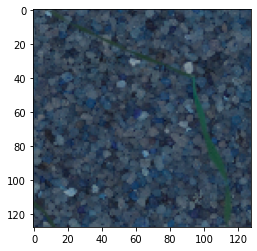

```python
# Sample image
i = 4000
image = images_np[i]
label = labels_df.iloc[i]
print(' Label \n Label Id: {} \n Name: {}'.format(label, label))
# print(f'Label \n Label Id: {label} \n Name: {label_dict[label]}')
plt.imshow(image);
```

```
Clipping input data to the valid range for imshow with RGB data ([0..1] for floats or [0..255] for integers).
```

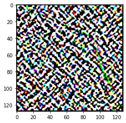

```python
# Image sobel output of a random image

sobel = cv2.Sobel(image, cv2.CV_64F, 1, 1, ksize=5)
plt.imshow(sobel)
```

**Insights**

1. Picture show lot of background image and noise impacting the picture.
2. This is evidennt in sobel output , we see an leaf in right bottom.

**Data Preprocessing**

As we noticed images has noise around the plant leaf, it is evident we need to reduce the noise.

Considering most of plant leaves are green, trying to do mask with green to extract right things to focus.

Also in below cells I have converted to grey scale.

Morphed image to high light ellipse (leaf sturcture).

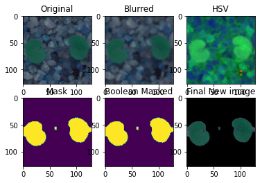

```
(<matplotlib.image.AxesImage at 0x7fa3c91d8110>, Text(0.5, 1.0, '4000'))
```

```python
new_images_np = []
sets = []; getEx = True
for i in images_np:
  # Guassian blurring.
    blurr = cv2.GaussianBlur(i,(5,5),0)
    # using HSV - Hue Saturation Value from image.
    hsv = cv2.cvtColor(blurr,cv2.COLOR_BGR2HSV)
    #Green Parameters
    lower = (25,40,50)
    upper = (75,255,255)
    mask = cv2.inRange(hsv,lower,upper)
    # Removing noice using morph ellipse
    struc = cv2.getStructuringElement(cv2.MORPH_ELLIPSE,(11,11))
    mask = cv2.morphologyEx(mask,cv2.MORPH_CLOSE,struc)
    boolean = mask>0
    new = np.zeros_like(i,np.uint8)
    new[boolean] = i[boolean]
    new_images_np.append(new)
    if getEx:
        plt.subplot(2,3,1);plt.imshow(i),plt.title('Original') # ORIGINAL
        plt.subplot(2,3,2);plt.imshow(blurr),plt.title('Blurred') # BLURRED
        plt.subplot(2,3,3);plt.imshow(hsv),plt.title('HSV') # HSV CONVERTED
        plt.subplot(2,3,4);plt.imshow(mask),plt.title('Mask') # MASKED
        plt.subplot(2,3,5);plt.imshow(boolean),plt.title('Boolean Masked') # BOOLEAN MASKED
        plt.subplot(2,3,6);plt.imshow(new),plt.title('Final New image') # NEW PROCESSED IMAGE
        plt.show()
        getEx = False
new_images_np = np.asarray(new_images_np)
# CLEANED IMAGES

# Checking the 4000 image

plt.subplot(2,4,7)
plt.imshow(new_images_np[4000]),plt.title(4000)
```

**Insights**

```python
new_images_np.shape
```

```
(4750, 128, 128, 3)
```

**Insights**

1. Verified the image size is same as original

*Converting to Grey Scale*

Converting the outcome to Grey scale, we will see redcution in dimension

```python
images_np_grey=np.zeros((4750,128,128))
for i in range(4750):
  images_np_grey[i] = cv2.cvtColor(new_images_np[i], cv2.COLOR_RGB2GRAY)
```

```
(4750, 128, 128)
```

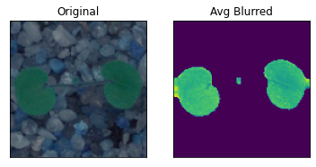

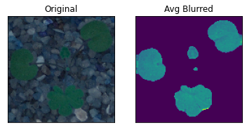

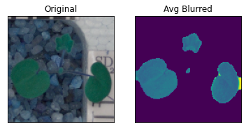

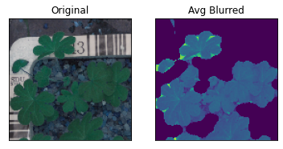

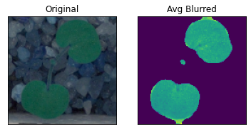

```python
print(images_np_grey.shape)
for i in range(5):
  plt.subplot(121),plt.imshow(images_np[i]),plt.title('Original')
  plt.xticks([]), plt.yticks([])
  plt.subplot(122),plt.imshow(images_np_grey[i]),plt.title('Avg Blurred')
  plt.xticks([]), plt.yticks([])
  plt.show()
```

**Insights**

1. After Grey scale conversion, images are clear and high light on the leaves part.
2. Above output shows we have mostly eliminated the noise and grey image is good to go.

```python
print("shape is ",images_np_grey.shape)
np.max(images_np_grey)
```

```
shape is  (4750, 128, 128)
```

```
255.0
```

**Insights**

1. Verified the image dimension reduced after gray scale conversion
2. Max value shows 255, which means we have to do normalization

*Normalizing the array*

Normalizing the np array dividing by 255.

```python
images_np_norm = images_np_grey.copy()
images_np_norm = images_np_grey.astype('float32')

"""Normalization"""
#Pixels are represented in the range [0-255],
#but the NN converges faster with smaller values, in the range [0-1].
images_np_norm = images_np_grey/255
```

*Visualize data after prepocessing*

```python
# Checking whether normalization worked by printing max (should be <= 1)
np.max(images_np_norm)
```

```
1.0
```

```python
np.min(images_np_norm)
```

```
0.0
```

**Insights on Normalization**

After normalizing the NP array, verified maximum and minumum in range of 0 and 1.

```python
labels_df['Label'].unique()
```

```
array(['Small-flowered Cranesbill', 'Fat Hen', 'Shepherds Purse',
       'Common wheat', 'Common Chickweed', 'Charlock', 'Cleavers',
       'Scentless Mayweed', 'Sugar beet', 'Maize', 'Black-grass',
       'Loose Silky-bent'], dtype=object)
```

```
([0, 1, 2, 3, 4, 5, 6, 7, 8, 9, 10, 11],
 <a list of 12 Text major ticklabel objects>)
```

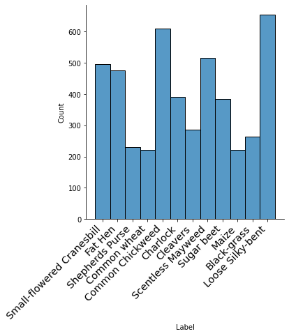

```python
plt.figure(figsize=(10,5))
chart = sns.displot(x="Label",data=labels_df)

plt.xticks(
    rotation=45,
    horizontalalignment='right',
    fontweight='light',
    fontsize='x-large'
)
```

```
([0, 1, 2, 3, 4, 5, 6, 7, 8, 9, 10, 11],
 <a list of 12 Text major ticklabel objects>)
```

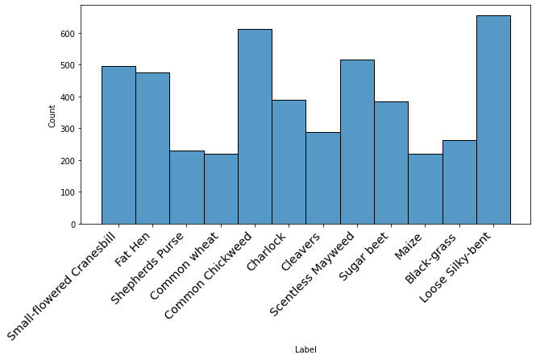

```python
plt.figure(figsize=(10,5))
chart = sns.histplot(x="Label",data=labels_df)

plt.xticks(
    rotation=45,
    horizontalalignment='right',
    fontweight='light',
    fontsize='x-large'
)
```

**Insights**

1. Silky bent plant seedlint are majority by 600+.
2. Common Chickweed is second most majority around 600.
3. Cheat wheat and Maize are lowest around 200.

**Make Data Compatible**

**One hot encoding for the output class** We have 12 labels, doing one hot encoding for the Label column

```python
# Converting labels to one hot encoding

label_df_form = pd.get_dummies(labels_df)
```

```python
label_df_form.iloc[0]
```

```
Label_Black-grass                  0
Label_Charlock                     0
Label_Cleavers                     0
Label_Common Chickweed             0
Label_Common wheat                 0
Label_Fat Hen                      0
Label_Loose Silky-bent             0
Label_Maize                        0
Label_Scentless Mayweed            0
Label_Shepherds Purse              0
Label_Small-flowered Cranesbill    1
Label_Sugar beet                   0
Name: 0, dtype: uint8
```

*Test train split*

*Splitting numpy array and df into three - Train Test and Validation*

Train - split of 70% in original Test - split of 15% from original Validation - Split of 15 % from original

```python
X_train, X_test, y_train, y_test = train_test_split(images_np_norm, label_df_form, test_size=.30, random_state=1,stratify=label_df_form)
```

```python
X_test, X_val, y_test, y_val = train_test_split(X_test, y_test, test_size=0.5, random_state=25)
```

```python
for data in [X_train,X_val,X_test,y_train,y_val,y_test]:

  print('+'*30)
  print(data.shape)
```

```
++++++++++++++++++++++++++++++
(3325, 128, 128)
++++++++++++++++++++++++++++++
(713, 128, 128)
++++++++++++++++++++++++++++++
(712, 128, 128)
++++++++++++++++++++++++++++++
(3325, 12)
++++++++++++++++++++++++++++++
(713, 12)
++++++++++++++++++++++++++++++
(712, 12)
```

**Insights**

**Reshape train and test sets into compatible shapes**

Sequential model in tensorflow.keras expects data to be in the format (n_e, n_h, n_w, n_c)

```python
X_train = X_train.reshape(X_train.shape[0], 128,128,1)
X_test = X_test.reshape(X_test.shape[0], 128,128,1)
X_val = X_val.reshape(X_val.shape[0],128,128,1)
print(X_train.shape)
print(X_test.shape)
```

```
(3325, 128, 128, 1)
(712, 128, 128, 1)
```

**Insights**

For keras, we have reshaped the data in required format.

**Deep Neural Network - Convolution Neural Networks**

```python
batch_size = 32
num_classes = 12
epochs = 100
num_predictions = 20
```

```python
# Set the CNN model

# batch_size = None

model = models.Sequential()
model.add(layers.Conv2D(32, (5, 5), padding='same', activation="relu", input_shape=X_train.shape[1:]))
model.add(layers.BatchNormalization())
model.add(layers.MaxPooling2D((2, 2)))
model.add(layers.Dropout(0.2))
model.add(layers.Conv2D(64, (5, 5), padding='same', activation="relu"))
model.add(layers.BatchNormalization())
model.add(layers.MaxPooling2D((2, 2)))
model.add(layers.Dropout(0.3))
model.add(layers.Conv2D(64, (3, 3), padding='same', activation="relu"))
model.add(layers.BatchNormalization())
model.add(layers.MaxPooling2D((2, 2)))
model.add(layers.Dropout(0.4))
model.add(layers.Conv2D(64, (3, 3), padding='same', activation="relu"))
model.add(layers.BatchNormalization())
model.add(layers.MaxPooling2D((2, 2)))
model.add(layers.Dropout(0.5))

model.add(layers.GlobalMaxPooling2D())
model.add(layers.Dense(256, activation="relu"))
model.add(layers.Dropout(0.5))
model.add(layers.Dense(12, activation="softmax"))

model.summary()
```

```
Model: "sequential_2"
_________________________________________________________________
Layer (type)                 Output Shape              Param #
=================================================================
conv2d_8 (Conv2D)            (None, 128, 128, 32)      832
_________________________________________________________________
batch_normalization_8 (Batch (None, 128, 128, 32)      128
_________________________________________________________________
max_pooling2d_8 (MaxPooling2 (None, 64, 64, 32)        0
_________________________________________________________________
dropout_10 (Dropout)         (None, 64, 64, 32)        0
_________________________________________________________________
conv2d_9 (Conv2D)            (None, 64, 64, 64)        51264
_________________________________________________________________
batch_normalization_9 (Batch (None, 64, 64, 64)        256
_________________________________________________________________
max_pooling2d_9 (MaxPooling2 (None, 32, 32, 64)        0
_________________________________________________________________
dropout_11 (Dropout)         (None, 32, 32, 64)        0
_________________________________________________________________
conv2d_10 (Conv2D)           (None, 32, 32, 64)        36928
_________________________________________________________________
batch_normalization_10 (Batc (None, 32, 32, 64)        256
_________________________________________________________________
max_pooling2d_10 (MaxPooling (None, 16, 16, 64)        0
_________________________________________________________________
dropout_12 (Dropout)         (None, 16, 16, 64)        0
_________________________________________________________________
conv2d_11 (Conv2D)           (None, 16, 16, 64)        36928
_________________________________________________________________
batch_normalization_11 (Batc (None, 16, 16, 64)        256
_________________________________________________________________
max_pooling2d_11 (MaxPooling (None, 8, 8, 64)          0
_________________________________________________________________
dropout_13 (Dropout)         (None, 8, 8, 64)          0
_________________________________________________________________
global_max_pooling2d_2 (Glob (None, 64)                0
_________________________________________________________________
dense_4 (Dense)              (None, 256)               16640
_________________________________________________________________
dropout_14 (Dropout)         (None, 256)               0
_________________________________________________________________
dense_5 (Dense)              (None, 12)                3084
=================================================================
Total params: 146,572
Trainable params: 146,124
Non-trainable params: 448
_________________________________________________________________
```

**Optimizer and Loss Function**

- optimizer - Adam
- Loss Function - Categorical cross entropy

```python
# initiate Adam optimizer
opt = optimizers.Adam(learning_rate=0.001, beta_1=0.9, beta_2=0.999, epsilon=1e-08)
```

```python
# Let's train the model using RMSprop
model.compile(loss='categorical_crossentropy',
              optimizer=opt,
              metrics=['accuracy'])
```

```python
model.summary()
```

```
Model: "sequential_2"
_________________________________________________________________
Layer (type)                 Output Shape              Param #
=================================================================
conv2d_8 (Conv2D)            (None, 128, 128, 32)      832
_________________________________________________________________
batch_normalization_8 (Batch (None, 128, 128, 32)      128
_________________________________________________________________
max_pooling2d_8 (MaxPooling2 (None, 64, 64, 32)        0
_________________________________________________________________
dropout_10 (Dropout)         (None, 64, 64, 32)        0
_________________________________________________________________
conv2d_9 (Conv2D)            (None, 64, 64, 64)        51264
_________________________________________________________________
batch_normalization_9 (Batch (None, 64, 64, 64)        256
_________________________________________________________________
max_pooling2d_9 (MaxPooling2 (None, 32, 32, 64)        0
_________________________________________________________________
dropout_11 (Dropout)         (None, 32, 32, 64)        0
_________________________________________________________________
conv2d_10 (Conv2D)           (None, 32, 32, 64)        36928
_________________________________________________________________
batch_normalization_10 (Batc (None, 32, 32, 64)        256
_________________________________________________________________
max_pooling2d_10 (MaxPooling (None, 16, 16, 64)        0
_________________________________________________________________
dropout_12 (Dropout)         (None, 16, 16, 64)        0
_________________________________________________________________
conv2d_11 (Conv2D)           (None, 16, 16, 64)        36928
_________________________________________________________________
batch_normalization_11 (Batc (None, 16, 16, 64)        256
_________________________________________________________________
max_pooling2d_11 (MaxPooling (None, 8, 8, 64)          0
_________________________________________________________________
dropout_13 (Dropout)         (None, 8, 8, 64)          0
_________________________________________________________________
global_max_pooling2d_2 (Glob (None, 64)                0
_________________________________________________________________
dense_4 (Dense)              (None, 256)               16640
_________________________________________________________________
dropout_14 (Dropout)         (None, 256)               0
_________________________________________________________________
dense_5 (Dense)              (None, 12)                3084
=================================================================
Total params: 146,572
Trainable params: 146,124
Non-trainable params: 448
_________________________________________________________________
```

**Adding other Params**

- Adding earlystopping to the model.
- Model Checkpoint - help tot save the weights when loss are low along the epoch

```python
#Adding Early stopping callback to the fit function is going to stop the training,
#if the val_loss is not going to change even '0.001' for more than 10 continous epochs
from tensorflow.keras.callbacks import ModelCheckpoint, EarlyStopping

early_stopping = EarlyStopping(monitor='val_loss', min_delta=0.001, patience=10)

#Adding Model Checkpoint callback to the fit function is going to save the weights whenever val_loss achieves a new low value.
#Hence saving the best weights occurred during training

model_checkpoint =  ModelCheckpoint('cifar_cnn_checkpoint_{epoch:02d}_loss{val_loss:.4f}.h5',
                                                           monitor='val_loss',
                                                           verbose=1,
                                                           save_best_only=True,
                                                           save_weights_only=True,
                                                           mode='auto',
                                                           period=1)
```

```
WARNING:tensorflow:`period` argument is deprecated. Please use `save_freq` to specify the frequency in number of batches seen.
```

[output not shown]

[output cut: 62 more lines]

```
Epoch 00052: val_loss did not improve from 0.98719

Epoch 00053: val_loss did not improve from 0.98719

Epoch 00054: val_loss did not improve from 0.98719

Epoch 00055: val_loss did not improve from 0.98719

Epoch 00056: val_loss did not improve from 0.98719

Epoch 00057: val_loss did not improve from 0.98719

Epoch 00058: val_loss did not improve from 0.98719

Epoch 00059: val_loss did not improve from 0.98719
```

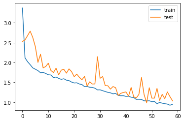

```python
history = model.fit(X_train,
                    y_train,
                    batch_size=batch_size,
                    epochs=epochs,
                    validation_data=(X_val, y_val),
                    shuffle=True,
                    verbose=1,
                    callbacks=[early_stopping,model_checkpoint])

# plot training history
plt.plot(history.history['loss'], label='train')
plt.plot(history.history['val_loss'], label='test')
plt.legend()
plt.show()
```

```python
print(history.history)
```

[output not shown]

**Cofusion Matrix**

Used metrics.multilabel_confusion_matrix since our output is multiclass

```python
# Function to create confusion matrix
# Adding X_test as argument so it can handle X_test and X_val
def make_confusion_matrix(model,y_actual,X_test,labels=[1, 0]):
    '''
    model : classifier to predict values of X
    y_actual : ground truth

    '''
    y_predict = model.predict(X_test)
    y_predict =  np.where(y_predict>0.5,1,0)
    cml=metrics.multilabel_confusion_matrix( y_actual, y_predict)
    print("cm is %s"%cml)
    for cm in cml:
      df_cm = pd.DataFrame(cm, index = [i for i in ["Actual - No","Actual - Yes"]],
                    columns = [i for i in ['Predicted - No','Predicted - Yes']])
      group_counts = ["{0:0.0f}".format(value) for value in
                  cm.flatten()]
      group_percentages = ["{0:.2%}".format(value) for value in
                          cm.flatten()/np.sum(cm)]
      labels = [f"{v1}\n{v2}" for v1, v2 in
                zip(group_counts,group_percentages)]
      labels = np.asarray(labels).reshape(2,2)
      plt.figure(figsize = (10,7))
      sns.heatmap(df_cm, annot=labels,fmt='')
      plt.ylabel('True label')
      plt.xlabel('Predicted label')
```

```python
model.metrics_names
```

```
['loss', 'accuracy']
```

*Testing the Model*

- We have build a model and trained with X_train and validated using X_val
- For Testing the model, we use X_test

```
cm is [[[670   0]
  [ 42   0]]

 [[641   0]
  [ 61  10]]

 [[674   2]
  [ 18  18]]

 [[606   7]
  [ 64  35]]

 [[678   1]
  [ 32   1]]

 [[641   4]
  [ 23  44]]

 [[584  31]
  [ 24  73]]

 [[673   0]
  [ 38   1]]

 [[642   2]
  [ 55  13]]

 [[677   0]
  [ 35   0]]

 [[606  28]
  [  5  73]]

 [[663   2]
  [ 23  24]]]
```

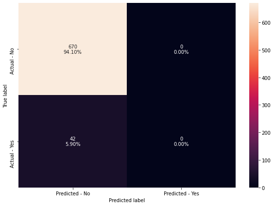

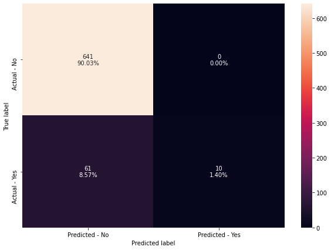

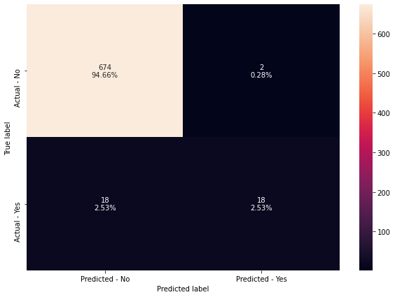

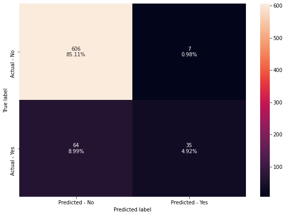

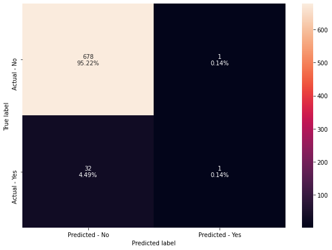

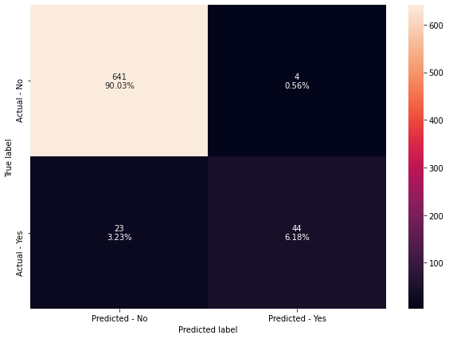

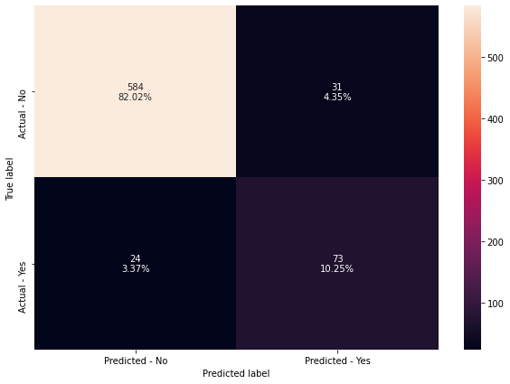

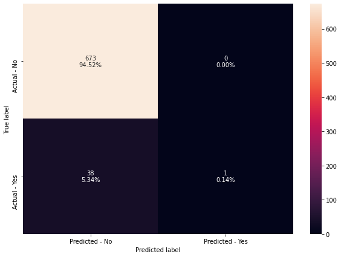

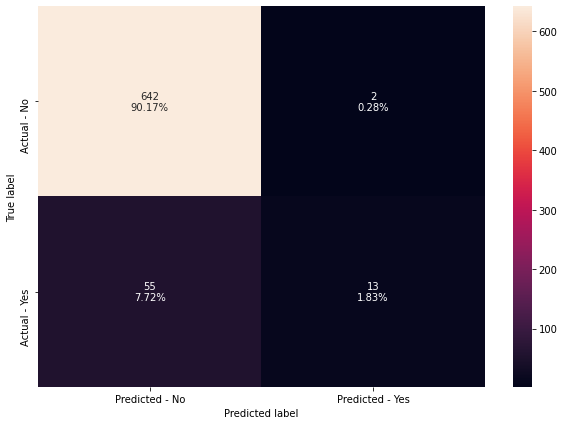

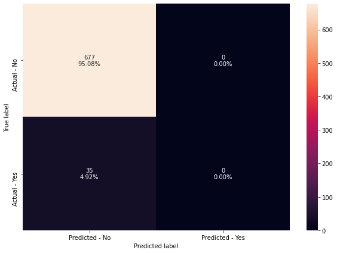

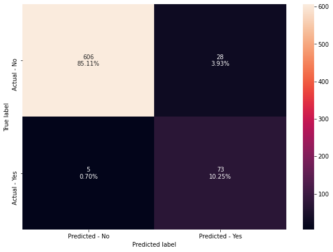

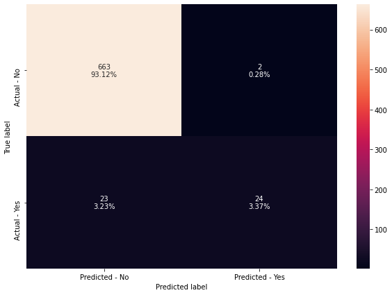

```python
make_confusion_matrix(model,y_test,X_test)
```

*Insights*

```python
# Score trained model.
pred_test = model.predict(X_test)
scores = model.evaluate(X_test, y_test, verbose=1)
print('Test loss:', scores[0])
print('Test accuracy:', scores[1])
```

```
Test loss: 1.0757097005844116
Test accuracy: 0.6432584524154663
```

*Insights overall accuracy is about 65% for the test data*

**Lets Visualize the Prediction**

- First lets predict the test images
- From predicted, get the class and print the plant name.
- Since data are normalized, lets have a threshold of 0.5, if it is above 0.5 we consider that as 1 or else 0
- From Actual image lets get the plant name.

```python
type(pred_test)
print(pred_test[36])
np.max(pred_test[36])
```

```
[4.51493834e-05 2.64151186e-01 1.18664399e-01 1.60743341e-01
 4.30721324e-03 8.73579923e-03 1.17918345e-04 2.13610334e-03
 4.13678400e-02 1.24114990e-01 2.73348123e-01 2.26791808e-03]
```

```
0.27334812
```

```python
ptest = np.where(pred_test>0.5,1,0)
```

```python
y_test.columns
```

```
Index(['Label_Black-grass', 'Label_Charlock', 'Label_Cleavers',
       'Label_Common Chickweed', 'Label_Common wheat', 'Label_Fat Hen',
       'Label_Loose Silky-bent', 'Label_Maize', 'Label_Scentless Mayweed',
       'Label_Shepherds Purse', 'Label_Small-flowered Cranesbill',
       'Label_Sugar beet'],
      dtype='object')
```

```python
X_test_orig = X_test.reshape(X_test.shape[0], 128,128)
```

```
+++++++++++++++ Prediction +++++++++++++++
[0 0 0 0 0 0 0 0 0 0 0 0]
Not able to predict
+++++++++++++++ Actual +++++++++++++++
Actual plant is Index(['Label_Scentless Mayweed'], dtype='object')
+++++++++++++++ +++++++++++++++ +++++++++++++++
```

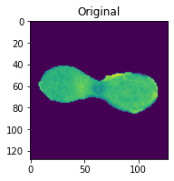

```
+++++++++++++++ +++++++++++++++ +++++++++++++++
+++++++++++++++ Prediction +++++++++++++++
[0 0 0 0 0 0 1 0 0 0 0 0]
Predicted plant is Label_Loose Silky-bent
+++++++++++++++ Actual +++++++++++++++
Actual plant is Index(['Label_Loose Silky-bent'], dtype='object')
+++++++++++++++ +++++++++++++++ +++++++++++++++
```

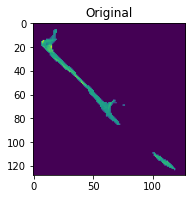

```
+++++++++++++++ +++++++++++++++ +++++++++++++++
+++++++++++++++ Prediction +++++++++++++++
[0 0 0 0 0 0 1 0 0 0 0 0]
Predicted plant is Label_Loose Silky-bent
+++++++++++++++ Actual +++++++++++++++
Actual plant is Index(['Label_Loose Silky-bent'], dtype='object')
+++++++++++++++ +++++++++++++++ +++++++++++++++
```

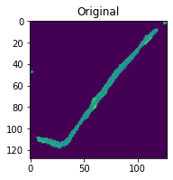

```
+++++++++++++++ +++++++++++++++ +++++++++++++++
+++++++++++++++ Prediction +++++++++++++++
[0 0 0 0 0 0 0 0 0 0 0 0]
Not able to predict
+++++++++++++++ Actual +++++++++++++++
Actual plant is Index(['Label_Charlock'], dtype='object')
+++++++++++++++ +++++++++++++++ +++++++++++++++
```

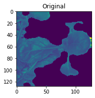

```
+++++++++++++++ +++++++++++++++ +++++++++++++++
+++++++++++++++ Prediction +++++++++++++++
[0 0 0 0 0 1 0 0 0 0 0 0]
Predicted plant is Label_Fat Hen
+++++++++++++++ Actual +++++++++++++++
Actual plant is Index(['Label_Fat Hen'], dtype='object')
+++++++++++++++ +++++++++++++++ +++++++++++++++
```

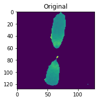

```
+++++++++++++++ +++++++++++++++ +++++++++++++++
```

```python
predict = []
actual = []
outcomes = y_test.columns
for i in [2,3,33,36,59]:
  print('+'*15,"Prediction",'+'*15,)
  print(ptest[i])
  if 1 in ptest[i]:
    loc = list(ptest[i]).index(1)
    # print("Location is %s"%loc)
    print('Predicted plant is %s'%outcomes[loc])
    predict.append(outcomes[loc])
  else:
    print("Not able to predict")
    predict.append('No correct prediction')
  print('+'*15,"Actual",'+'*15,)
  print('Actual plant is %s'%y_test.iloc[i][y_test.iloc[i]==1].index)
  actual.append(y_test.iloc[i][y_test.iloc[i]==1].index)
  print('+'*15,"+"*15,'+'*15,)
  # print(y_test.iloc[i])
  # cv2.cvtColor(blurr,cv2.COLOR_BGR2HSV)
  # col_image = cv2.cvtColor(X_test[i],cv2.COLOR_GRAY2RGB)
  # plt.subplot(121),plt.imshow(col_image),plt.title('Original')
  # plt.xticks([]), plt.yticks([])
  plt.subplot(121),plt.imshow(X_test_orig[i]),plt.title('Original')
  label = y_test.iloc[i]

  # print(label)
  plt.show()

  print('+'*15,"+"*15,'+'*15,)
```

```python
result = pd.DataFrame(list(zip(actual, predict)),
               columns =['actual', 'predict'])
```

```python
result
```

|  | actual | predict |
| --- | --- | --- |
| 0 | Index(['Label_Scentless Mayweed'], dtype='obje... | No correct prediction |
| 1 | Index(['Label_Loose Silky-bent'], dtype='object') | Label_Loose Silky-bent |
| 2 | Index(['Label_Loose Silky-bent'], dtype='object') | Label_Loose Silky-bent |
| 3 | Index(['Label_Charlock'], dtype='object') | No correct prediction |
| 4 | Index(['Label_Fat Hen'], dtype='object') | Label_Fat Hen |

**Summary of outcomes for x_test[2], x_test[3], x_test[33], x_test[36], x_test[59]**

1. Out of 5 , 3 prediction is good and 2 prediction is wrong.
2. Accuracy is 60% as predicted earlier